# Adatvizualizáció I.

A geometriai megjelenítési módok mellett az is megválasztható, hogy milyen statisztikai transzformációt végezzünk az adatokon, de (számunkra legalább is) általában kényelmesebb és hatékonyabb először transzformálni az adatokat, és ezt követően az új data.frame-ből ggplot ábrát készíteni. A statisztikai transzformációkra példaként készítsük el a 2007-es résztvevő országok gyakorisági diagramját kontinensenként.

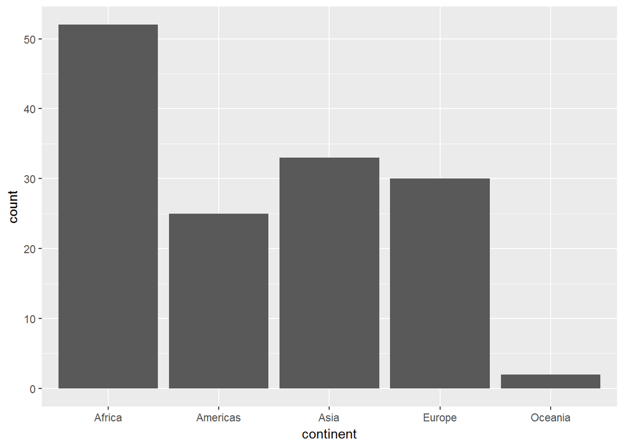

```r
# Az aggregálást a stat_count függvény segítségével végezzük el
# A stat_count()-hoz tartozó default geometriai megjelenítés a geom_bar()
ggplot(data = gapminder_2007) +
  stat_count(mapping = aes(x = continent))
```

```r
# A table függvénnyel ellenőrizhetjük az aggregáció helyességét
table(gapminder_2007$continent)
```

```
##
##   Africa Americas     Asia   Europe  Oceania
##       52       25       33       30        2
```

Az egyes statisztikai transzformációkhoz hozzá van rendelve egy-egy default geometriai megjelenítési mód. A `stat_count()` esetében mint láttuk a `geom_bar()`. Ha nem módosítjuk az alapbeállításokat, akkor `stat_count()` alkalmazásakor oszlopdiagramot kapunk. Hasonlóan a geometriai megjelenítési módokhoz is tartoznak default statisztikai transzformációk. Ha egy ggplot ábrán `geom_bar()` megjelenítési módot használunk, és nem módosítjuk az alapbeállításokat, akkor a függvény által alkalmazott transzformáció a `stat="count"` lesz. A geomatriai megjelenítési módok és statisztikai transzformációk alapbeállítását, mint minden más paramétert, felül lehet írni. (Az előre aggregált adatokon a `geom_col()` függvényt használtuk korábban, ahol közvetlenül adtuk meg az oszlopmagasságokat, és nem a függvény kalkulálta azokat.)

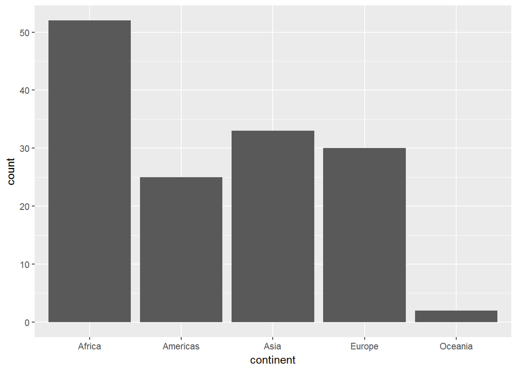

```r
# A geom_bar() függvény az előzővel azonos eredményt ad
# A default statisztikai transzformáció a count
ggplot(data = gapminder_2007) +
  geom_bar(mapping = aes(x = continent))
```

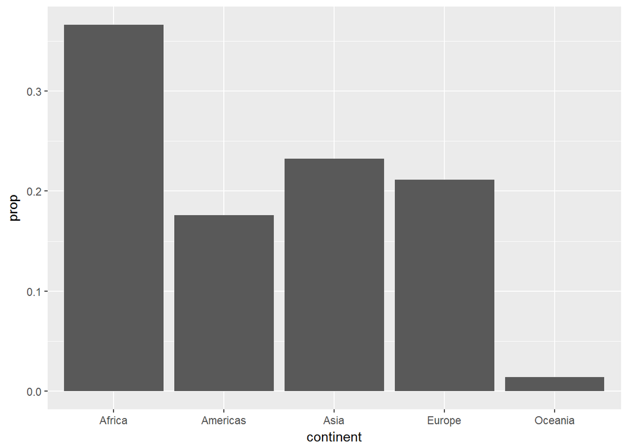

```r
# A default statisztika felülírható
# ..prop.. használatával például sűrűség ábrát kapunk.
ggplot(data = gapminder_2007) +
  geom_bar(mapping = aes(x = continent, y = ..prop.., group = 1)) # default: group = continent
```

```r
# Az értékeket ismét ellenőrizhetjük egy táblázattal
prop.table(table(gapminder_2007$continent))
```

```
##
##     Africa   Americas       Asia     Europe    Oceania
## 0.36619718 0.17605634 0.23239437 0.21126761 0.01408451
```

A második chart esetében látható `group = 1` paraméternél egy “dummy” group változót adunk meg. A `geom_bar()` alapesetben a statisztikai transzformációt az x tengelyen meghatározott kategóriánként végzi pl. kontinensenként összeszámolja az országokat. Ha a sűrűséget szeretnénk ábrázolni, akkor az alapbeállítás mellett minden kontinens esetében egységnyi hosszúságú oszlopot látnánk, egy adott kategórián belül az adott kategória aránya 100%. A “dummy” group változóval érjük el, hogy az összes kategórián belül számolja a függvény az egyes kategóriák megoszlását. A változó “dummy” változó, mert nem szerepel az adattáblában, értéke tetszőleges.

A sűrűség diagram “dummy” group változó nélkül:

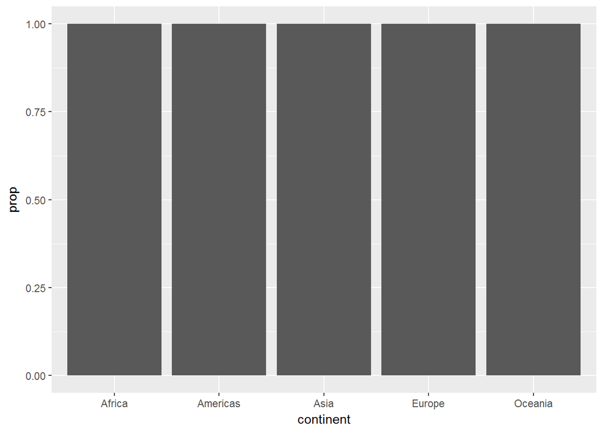

```r
# A kalkuláció alapbeállítások mellet x kategóriánként történik
ggplot(data = gapminder_2007) +
  geom_bar(mapping = aes(x = continent, y = ..prop..)) # default: group = continent
```

Végül nézzük meg, hogyan készíthetőek el ugyanezek a chart típusok kategóriákra bontva. Példaként a kontinensek népesség szerinti megoszlását fogjuk előállítani az egyes évekre.

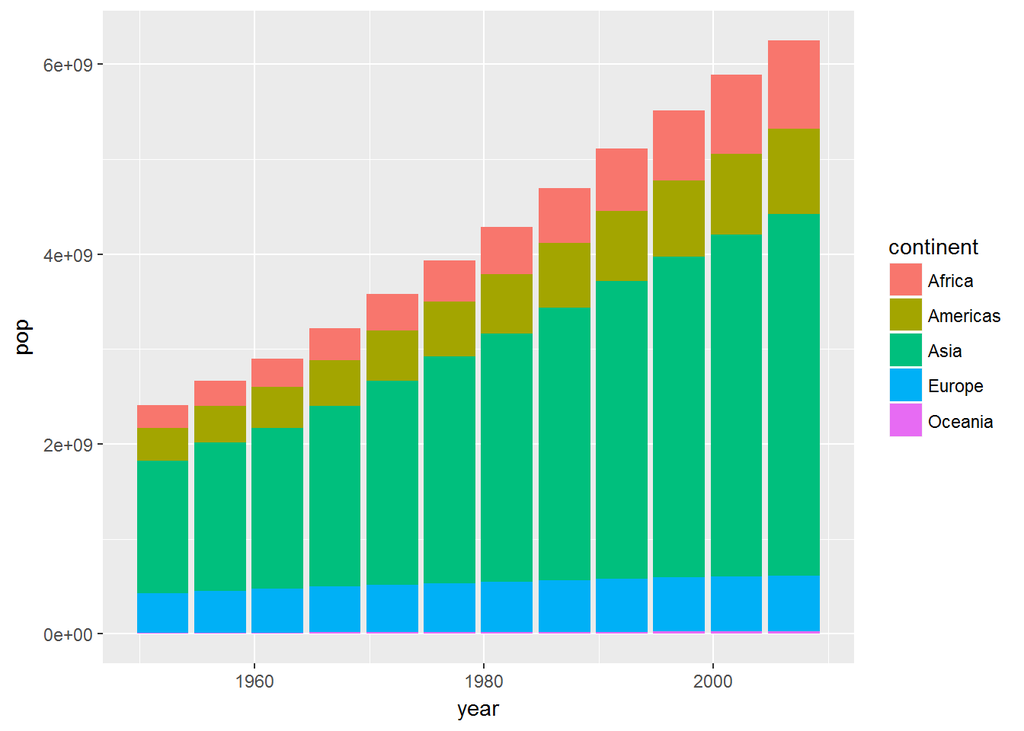

```r
# A kontinensek népesség szerinti megoszlása a mintában az egyes években
ggplot(data = gapminder) +
  geom_col(mapping = aes(x = year, y=pop, fill = continent))
```

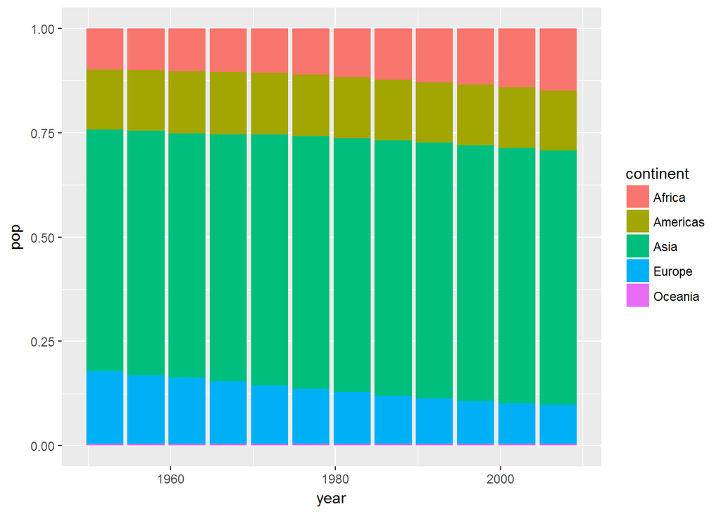

```r
# A kontinensek népesség szerinti aránya a mintában az egyes években
ggplot(data = gapminder) +
  geom_col(mapping = aes(x = year, y=pop, fill = continent), position = "fill")
```

```r
# Az adatok táblázatos formában
gapminder_continent_pop_summary <- gapminder %>%
  group_by(year, continent) %>%
  # Először kontinensenként összegzzük a népességszámot millióban mérve
  summarise (continent_total_pop_m = sum(pop/1000000)) %>%
  mutate(# Az egyes kontinensek népesség szerinti arányát 2 tizedesjegyik jelenítjük meg
         prop = format(round(continent_total_pop_m / sum(continent_total_pop_m),2), nsmall = 2),
         # Az előbb létrehozott változót egész milliókra kerekítjük
         continent_total_pop_m = round(continent_total_pop_m))

head(gapminder_continent_pop_summary)
```

```
## # A tibble: 6 x 4
## # Groups: year [2]
##    year continent continent_total_pop_m prop
##   <int> <fct>                     <dbl> <chr>
## 1  1952 Africa                    238   0.10
## 2  1952 Americas                  345   0.14
## 3  1952 Asia                     1395   0.58
## 4  1952 Europe                    418   0.17
## 5  1952 Oceania                    11.0 0.00
## 6  1957 Africa                    265   0.10
```

```r
tail(gapminder_continent_pop_summary)
```

```
## # A tibble: 6 x 4
## # Groups: year [2]
##    year continent continent_total_pop_m prop
##   <int> <fct>                     <dbl> <chr>
## 1  2002 Oceania                    23.0 0.00
## 2  2007 Africa                    930   0.15
## 3  2007 Americas                  899   0.14
## 4  2007 Asia                     3812   0.61
## 5  2007 Europe                    586   0.09
## 6  2007 Oceania                    25.0 0.00
```

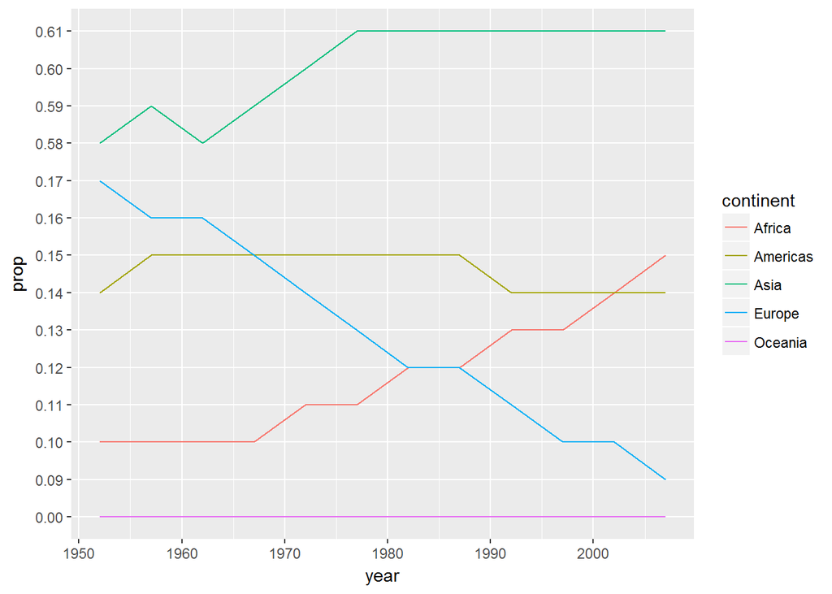

```r
# A népesség szerinti arány alakulását ábrázolhatjuk vonaldiagrammal is
ggplot(data=gapminder_continent_pop_summary, aes(x=year, y=prop, color=continent, group = continent)) +
  # Nem minden évre van adatunk,
  # a group paraméter adja meg, hogy melyik pontok legyenek összekötve
  geom_line()
```